# История и перспективы приватизации в Украине

##### Рис.10. Среднестатистическая стоимость 1го объекта приватизации по годам (ном.тыс.дол.США)

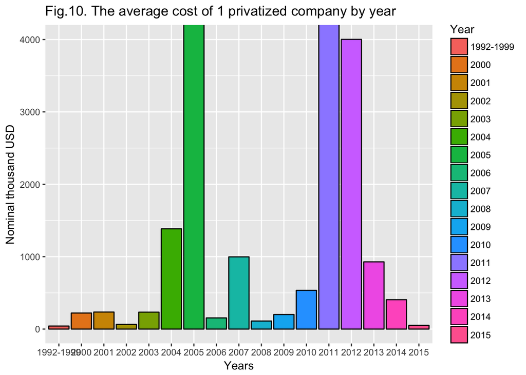

```r
ggplot(data = avercost, aes(x = Year, y = `Nominal thousand USD for 1 company`, fill = Year))+
        geom_bar(colour="black", stat = "identity")+

        coord_cartesian(ylim=c(0, 4000))+
        xlab("Years")+
        ylab("Nominal thousand USD")+
        ggtitle("Fig.10. The average cost of 1 privatized company by year")
```

Кроме того, следует отметить, что приватизация предприятия, как и любая другая смена владельца, зачастую, влечет за собой реструктуризацию, а следовательно, увольнение людей. Поскольку люди, работающие на государственных предприятиях, социально защищены гораздо лучше, чем в частной структуре, все они пользуются системой «социальной защиты», становятся на биржу труда, регистрируются в центрах занятости. Общие затраты государства на 1-го безработного, проходящего через систему социальной защиты, как прямые (выплаты пособий, переобучение, и.т.д.) так и косвенные (зарплаты социальных работников, содержание офисов центров занятости, и т.д.), составляют примерно 5 тыс.евро на человека по оценкам эксперта аналитической платформы VoxUkraine Люка Ванкраена[^10]. Этот же эксперт, в своей статье *Outsourcing Privatization In Ukraine To Attract Capital And Raise Efficiency (Аутсорсинг приватизации в Украине для привлечения капитала и повышения эффективности)* отмечает, что в результате приватизации только за последние 5 лет более 500 тыс.чел. попали в систему социальной зашиты, потеряв работу из-за реструктуризации предприятия, сменившего собственника. Путем несложных расчетов можно убедиться, что, к сожалению, за последние 5 лет на социальные выплаты, переквалификацию, поиск нового места работы, и т.д. для людей, потерявших работу из-за того, что предприятия, где они работали ранее, были приватизированы, государство потратило примерно 2,5 млрд. евро, а «заработало» на приватизации всего 2,134 млрд. (примерно на 20% меньше).